# Étude Data Science : Ventes de rollers

Statistiques descriptives, modélisation et séries temporelles

Issam L

08 juillet 2026

# Contexte et objectifs

Ce rapport porte sur les **ventes horaires de rollers** (2011–2012). Les objectifs sont :

1. **Statistiques descriptives** — tendances, facteurs influençant la demande, graphiques commentés
2. **Machine Learning** — prédire `count` pour chaque heure du jeu test
3. **Interprétation** — restitution claire des résultats

**Variable cible :** `count` (total horaire).

# 1. Chargement et audit des données

```r
raw   <- load_data()   # retourne list(train=..., test=...) — voir solution_rollers.R
train <- coerce_types(raw$train, has_target = TRUE)  # has_target=FALSE pour le jeu test (pas de count)

# nrow() : nombre de lignes ; raw$train accède à l'élément nommé "train" de la liste
cat("Train :", nrow(raw$train), "lignes · Test :", nrow(raw$test), "lignes\n")
```

```
## Train : 10886 lignes · Test : 6493 lignes
```

```r
# results='asis' : la sortie texte de cat()/print() est interprétée comme du Markdown/HTML
audit_raw_data(raw)
```

========== AUDIT DES DONNÉES BRUTES ==========

**Dimensions**

Train : 10886 lignes x 12 colonnes  
Test : 6493 lignes x 9 colonnes

**Colonnes train :** datetime, season, holiday, workingday, weather, temp, atemp, humidity, windspeed, casual, registered, count

**Colonnes test :** datetime, season, holiday, workingday, weather, temp, atemp, humidity, windspeed

Cibles absentes du test : casual, registered, count

**Types bruts (avant conversion)**

windspeed, casual, registered : **character** (pas numeric)  
read.csv2() garde du texte tant qu’il y a des cellules vides ou des valeurs ambiguës dans la colonne.

**Synthèse des manquants — données brutes du CSV (fichier disque inchangé)**

is.na() = **0 partout** juste après lecture : normal. En R, une cellule vide lue en character devient `""`, pas NA.

| Variable | Forme du manquant | N |
| --- | --- | --- |
| season | cellule vide `""` | 268 |
| holiday | cellule vide `""` | 73 |
| workingday | cellule vide `""` | 131 |
| weather | cellule vide `""` | 53 |
| casual | cellule vide `""` | 6 |
| registered | cellule vide `""` | 2 |
| windspeed | code `0` (vent absent, pas un NA R) | 1313 |
| season | valeur hors plage (ex. -2, 1.5 ) | 126 |
| workingday | valeur hors plage (ex. 3 ) | 90 |

**Après coerce_types() — copie en mémoire uniquement**

as.numeric() transforme `""` en NA. Comptage is.na() :

season : 291 NA  
holiday : 73 NA  
workingday : 131 NA  
weather : 53 NA  
casual : 6 NA  
registered : 2 NA  
windspeed : 1313 codes 0 restants (imputés section suivante, pas des NA).

**Cohérence count = casual + registered**

Lignes incohérentes : 0

**Valeurs catégorielles — détail NA + hors plage (après as.numeric sur le brut)**

season : 291 NA, 126 valeurs aberrantes (ex. : -2, 1.5)  
holiday : 73 NA, 0 valeurs aberrantes  
workingday : 131 NA, 90 valeurs aberrantes (ex. : 3)  
weather : 53 NA, 0 valeurs aberrantes

**Points clés de l’audit :**

- Les CSV **d’origine ne sont jamais modifiés** — lecture seule ; écriture uniquement dans `output/`.
- `is.na() = 0` au chargement : les manquants sont des `""`, des `0` (windspeed) ou des valeurs hors plage — voir le **tableau synthèse** dans l’audit.
- Après `coerce_types()` (en mémoire) : les `""` deviennent des NA R (ex. season : 291 NA).
- Valeurs aberrantes → imputées en section 2, toujours **sans toucher au CSV**.
- Train et test : **échantillons d’heures disjoints** (pas de dates communes).

# 2. Imputation des valeurs manquantes

Stratégie non naïve :

| Variable | Méthode |
| --- | --- |
| `season` | Dérivée du mois calendaire |
| `holiday` / `workingday` | Cohérence week-end / jours ouvrés |
| `weather` | Régression sur température, humidité, saison |
| `windspeed = 0` | Régression météo (modèle conservé pour le test) |
| `casual` / `registered` | Contrainte `count = casual + registered` |

```r
imp         <- impute_missing(train)       # retourne list(data=..., windspeed_model=...)
df          <- prepare_tidy(imp$data)      # mutate dplyr + facteurs lisibles — solution_rollers_advanced.R
windspeed_m <- imp$windspeed_model         # modèle réutilisé pour imputer le test de la même façon

# knitr::kable() : tableau formaté pour le rapport (alternative : DT::datatable pour interactif)
knitr::kable(
  data.frame(
    variable = c("season", "holiday", "workingday", "weather", "windspeed", "casual", "registered"),
    # imp$data[c(...)] : sous-ensemble de colonnes par nom (syntaxe base R)
    NA_apres = as.integer(count_na(imp$data[c("season","holiday","workingday","weather","windspeed","casual","registered")]))
  ),
  caption = "Valeurs manquantes après imputation (train)"
)
```

Valeurs manquantes après imputation (train)

| variable | NA_apres |
| --- | --- |
| season | 0 |
| holiday | 0 |
| workingday | 0 |
| weather | 0 |
| windspeed | 0 |
| casual | 0 |
| registered | 0 |

# 3. Statistiques descriptives

La demande horaire est **asymétrique à droite** (pics de pointe) : une GLM Poisson ou une transformation `log(1+count)` est mathématiquement justifiée.

```r
run_descriptive_advanced(df)  # calcule stats + sauvegarde les PNG dans output_advanced/
```

```
##
## ## 1. STATISTIQUES DESCRIPTIVES DE count
##
## La variable cible count suit une loi empirique à support [1, 977].
## Moyenne μ = 191.57, écart-type σ = 181.14, coefficient de variation CV = σ/μ = 0.946.
## CV proche de 1 : forte variabilité relative autour de la moyenne.
## Skewness γ₁ = 1.242 → distribution asymétrique à droite (queue vers les grandes valeurs).
## Interprétation : la majorité des heures ont une demande modérée, mais
## quelques pics (heures de pointe) tirent la moyenne vers le haut.
## Modéliser log(1+count) ou une GLM Poisson est mathématiquement justifié
```

```
##
## Profil temporel : pic à 17h, creux à 4h.
## Mathématiquement, E[count|hour=h] est une fonction périodique discrète
## de période 24 — modélisable par splines ou variable hour en régression.
```

```
## $hourly
## # A tibble: 24 × 3
##     hour mean_count sd_count
##    <int>      <dbl>    <dbl>
##  1     0      55.1     43.6
##  2     1      33.9     34.1
##  3     2      22.9     26.1
##  4     3      11.8     12.7
##  5     4       6.41     4.22
##  6     5      19.8     12.8
##  7     6      76.3     54.7
##  8     7     213.     159.
##  9     8     363.     232.
## 10     9     222.      92.1
## # ℹ 14 more rows
##
## $plots
## $plots$p1
```

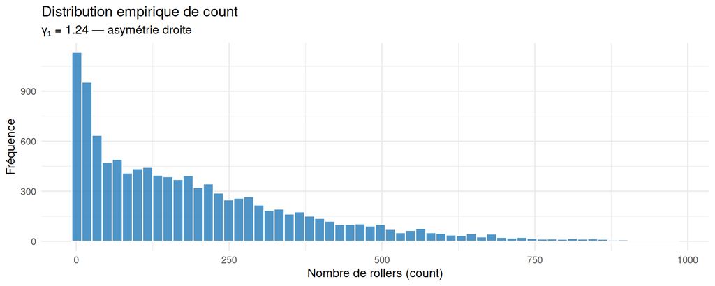

```
##
## $plots$p2
```

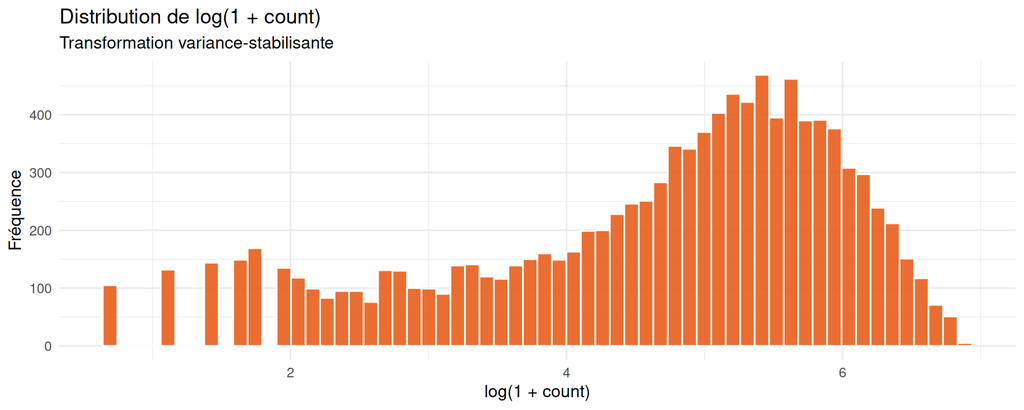

```
##
## $plots$p_hour
```

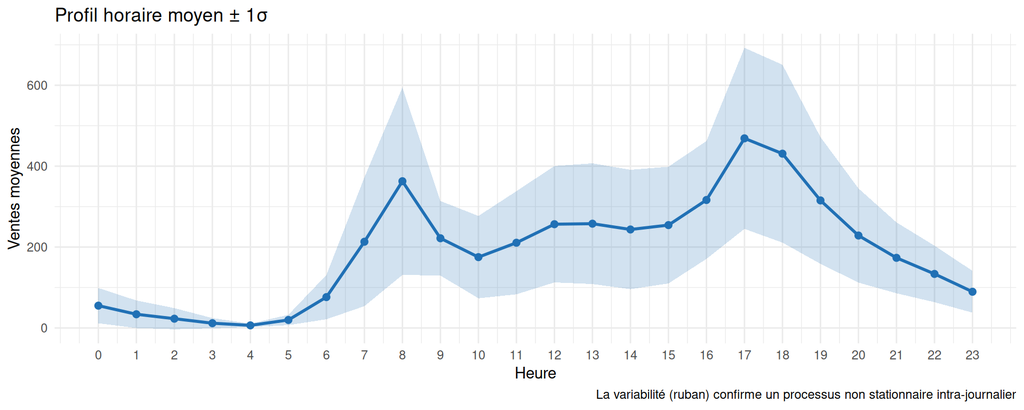

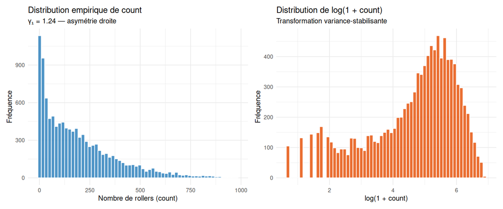

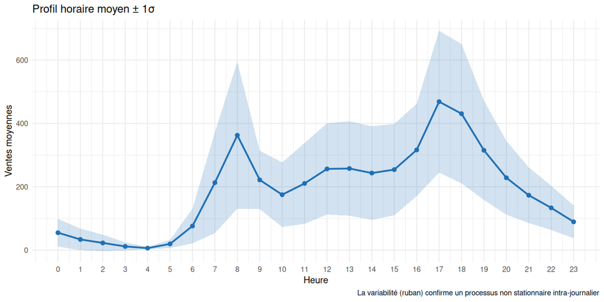

**Interprétation :**

- Pic de demande vers **17h**, creux vers **4h** — profil circadien typique des déplacements.
- `E[count | hour]` est une fonction **périodique** de période 24 h.

# 4. Corrélations et liens linéaires

```r
run_correlation_analysis(df)
```

```
##
## ## 2. ANALYSE DES CORRÉLATIONS
##
## Matrice de corrélation de Pearson — interprétation des liens linéaires :
##   • registered : corrélation très forte positive (r = 0.971)
##   • log_count : corrélation très forte positive (r = 0.82)
##   • casual : corrélation forte positive (r = 0.69)
##   • hour : corrélation modérée positive (r = 0.401)
##   • temp : corrélation faible positive (r = 0.394)
##   • atemp : corrélation faible positive (r = 0.39)
##   • month : corrélation négligeable positive (r = 0.167)
##   • windspeed : corrélation négligeable positive (r = 0.1)
##   • weekday : corrélation négligeable négative (r = -0.002)
##   • humidity : corrélation faible négative (r = -0.317)
##
## Note mathématique : r mesure une association LINÉAIRE.
## Le lien hour → count est plutôt périodique ; r sous-estime la force réelle.
## temp et atemp sont colinéaires (r ≈ 0.985) — une seule suffit souvent en régression.
```

```
##
## Régression simple count ~ temp : R² = 0.1556 → 15.6% de variance expliquée linéairement.
## Régression simple count ~ humidity : R² = 0.1007 (effet négatif attendu).
```

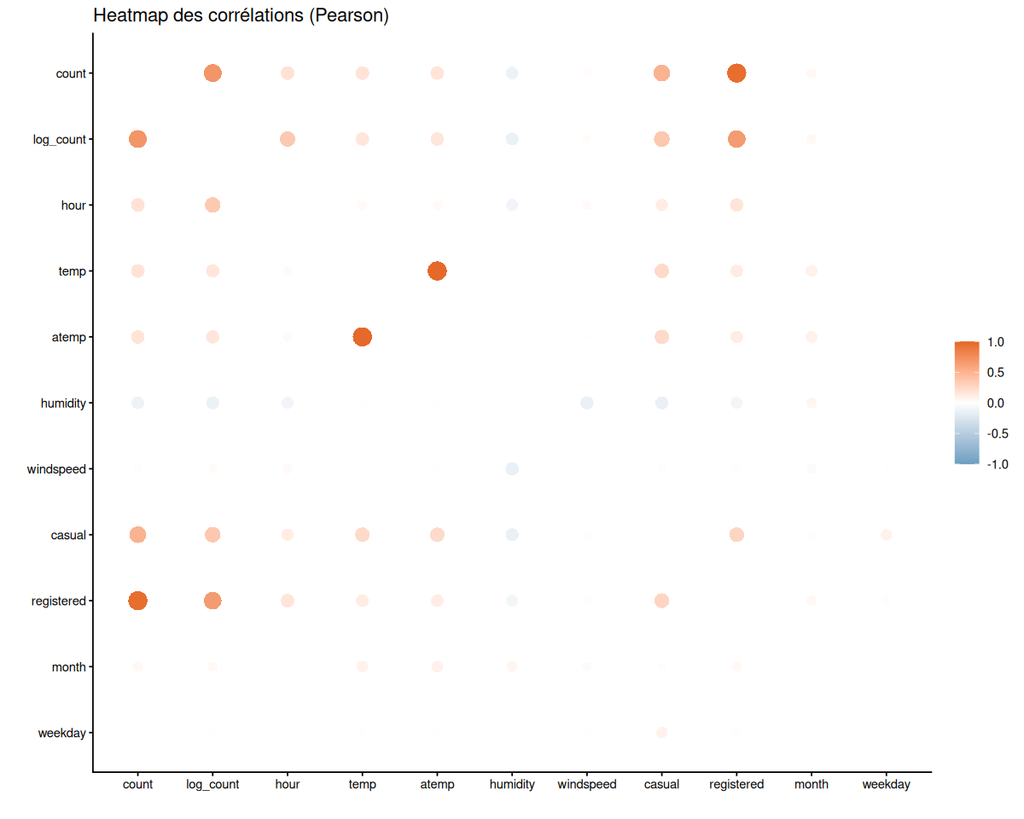

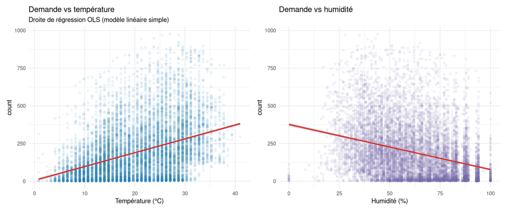

**Interprétation :**

- `registered` très corrélé à `count` (r ≈ 0,97) — structure additive du volume.
- `temp` ↑ et `humidity` ↓ associés à plus de demande (liens linéaires modestes, R² ≈ 16 % et 10 %).
- `temp` et `atemp` colinéaires (r ≈ 0,99) → une seule suffit en régression.
- Pearson **sous-estime** l’effet de `hour` (relation périodique, pas linéaire).

# 5. ANOVA — effets catégoriels

Modèle : `count_ij = μ + α_i + ε_ij` — test d’égalité des moyennes de groupes.

```r
run_anova_advanced(df)
```

```
##
## ## 3. ANALYSE DE VARIANCE (ANOVA à un facteur)
##
## Modèle : count_ij = μ + α_i + ε_ij, avec test H0 : tous les α_i = 0
## (ANOVA teste l'égalité des moyennes de groupes, pas la causalité.)
##
## --- Saison ---
##   F = 232.56, p = <1e-10, effet moyen (η² = 0.0602)
##   → Rejet de H0 : les moyennes de count diffèrent selon Saison.
## --- Météo ---
##   F = 65.67, p = <1e-10, effet faible (η² = 0.0178)
##   → Rejet de H0 : les moyennes de count diffèrent selon Météo.
## --- Week-end ---
##   F = 1.07, p = 0.3, effet négligeable (η² = 1e-04)
##   → Non rejet de H0 au seuil 5% : pas de preuve statistique d'un effet.
## --- Jour férié ---
##   F = 0.32, p = 0.574, effet négligeable (η² = 0)
##   → Non rejet de H0 au seuil 5% : pas de preuve statistique d'un effet.
```

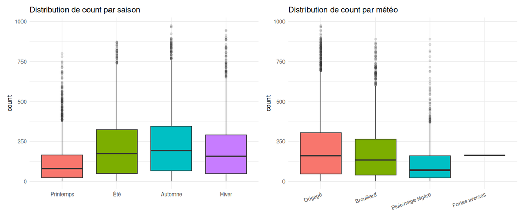

**Interprétation (η² = part de variance expliquée) :**

- **Saison** : effet moyen (η² ≈ 6 %), p < 10⁻¹⁰.
- **Météo** : effet faible mais significatif (η² ≈ 2 %).
- **Week-end / férié** : non significatifs seuls au seuil 5 %.

# 6. ACP — structure multivariée

Analyse en composantes principales sur variables quantitatives centrées-réduites.

```r
run_pca_analysis(df)
```

```
##
## ## 4. ANALYSE EN COMPOSANTES PRINCIPALES (ACP)
##
## Objectif : réduire le nuage des variables quantitatives dans ℝ^p
## en axes orthogonaux maximisant la variance expliquée.
##
## Méthode : FactoMineR::PCA (données centrées-réduites).
## Valeurs propres (inertie) :
##   Dim 1 : λ = 3.499 (43.7% de variance, cumul 43.7%)
##   Dim 2 : λ = 1.628 (20.3% de variance, cumul 64.1%)
##   Dim 3 : λ = 1.049 (13.1% de variance, cumul 77.2%)
##   Dim 4 : λ = 0.733 (9.2% de variance, cumul 86.4%)
##   Dim 5 : λ = 0.632 (7.9% de variance, cumul 94.3%)
##
## Interprétation mathématique :
##   • Matrice X centrée-réduite ; ACP = décomposition spectrale de cor(X).
##   • λ_k = variance expliquée par l'axe k ; Σ λ_k / p = 100%.
##   • Les cosinus carrés mesurent la qualité de projection des variables.
##   • count, casual et registered sont colinéaires → même direction sur PC1.
##   • hour structure un axe temporel circadien distinct de la météo.
```

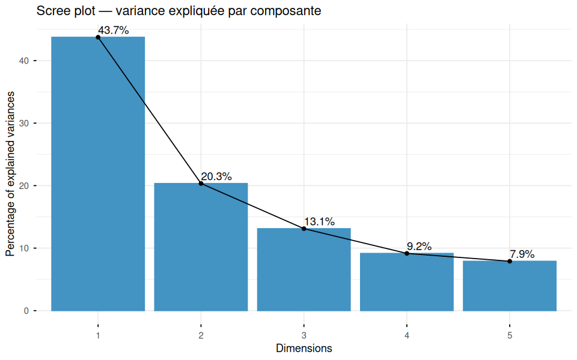

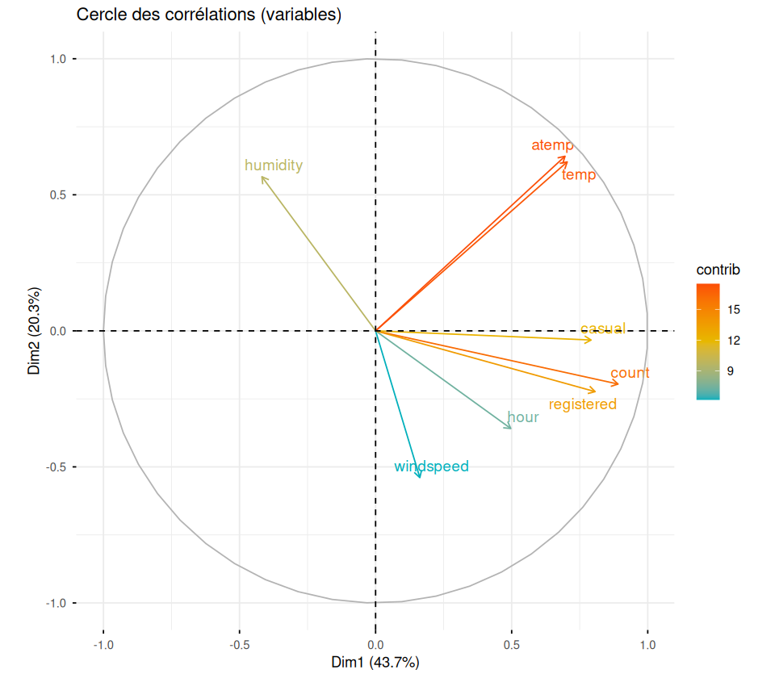

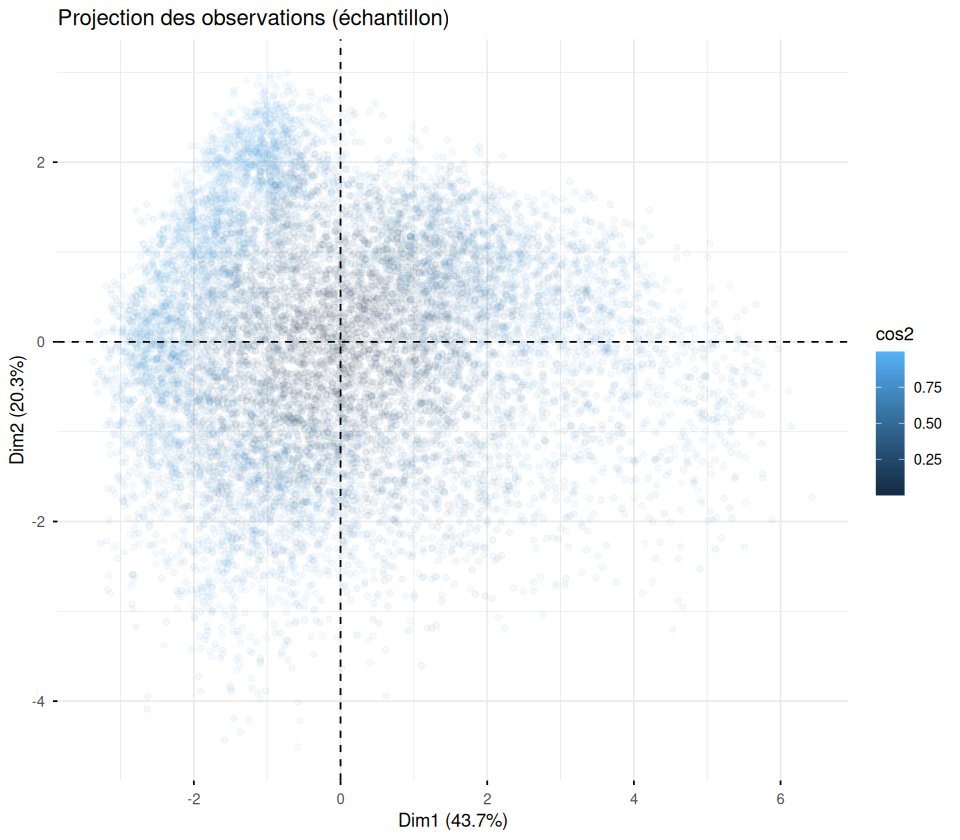

**Interprétation :**

- **PC1 ≈ 44 %** : intensité de la demande + température.
- **PC1 + PC2 ≈ 64 %** du nuage.
- `count`, `casual`, `registered` colinéaires sur PC1 ; `humidity` orientée opposée.
- `hour` structure un axe **circadien** distinct de la météo.

# 7. Inférence OLS (régression multiple)

Modèle linéaire exploratoire — utile pour l’inférence, moins pour la prédiction (hétéroscédasticité).

```r
run_regression_inference(df)
```

[output not shown]

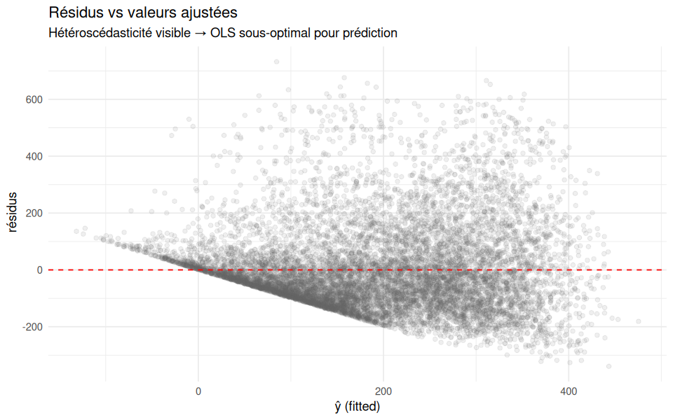

**Interprétation :**

- R² ajusté ≈ **34 %** — le linéaire capture une partie du signal.
- Résidus en entonnoir → violation d’homoscédasticité ; OLS **sous-optimal** pour prédire des comptages.

# 8. Modélisation prédictive

Comparaison par **validation croisée 5-fold** (critère RMSE).

```r
ev <- evaluate_models_advanced(df)  # ~2 min : RF + validation croisée 5-fold
```

```
##
## ## 5. MODÉLISATION PRÉDICTIVE
##
## Critère : RMSE = √(mean((y - ŷ)²)) sur validation croisée 5-fold.
## RMSE pénalise fortement les grandes erreurs (convexité quadratique).
##
## RMSE moyenne (5-fold) :
##   • GLM Poisson : 148.98
##     E[count|X] = exp(Xβ), loi Poisson, lien log canonique
##   • Régression log-transformée : 166.08
##     log(1+count) = Xβ + ε, prédiction ŷ = exp(Xβ) - 1
##   • Forêt aléatoire : 65.44
##     Moyenne de B arbres CART ; capture non-linéarités et interactions
##   • Arbre de régression CART : 104.92
##     Partition récursive minimisant la variance intra-nœud
##
## Modèle retenu : Forêt aléatoire (RMSE = 65.44)
##
## Importance des variables (Random Forest — %IncMSE) :
##   • hour : 226.7
##   • temp : 66.5
##   • humidity : 50.5
##   • weekday : 50.3
##   • workingday : 50
##   • weather : 37.2
## Interprétation : permuter une variable importante dégrade fortement
## la prédiction → forte pouvoir explicatif marginal.
```

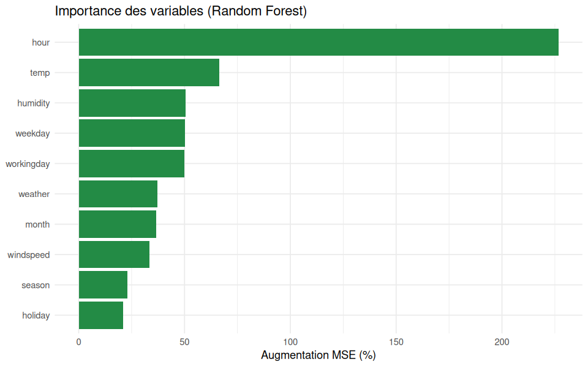

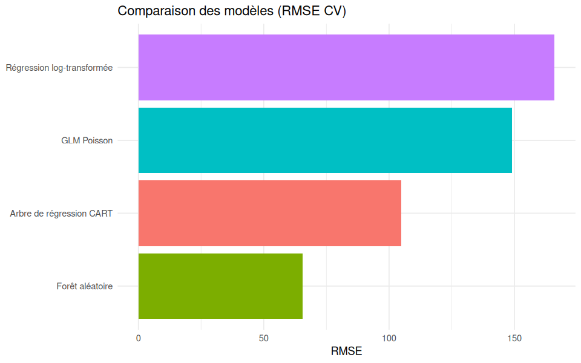

**Résultats :**

| Modèle | RMSE CV (approx.) |
| --- | --- |
| GLM Poisson | ~149 |
| Régression log | ~166 |
| CART (rpart) | ~105 |
| **Random Forest** | **~65** ← retenu |

Variable clé (RF) : **`hour`**, puis `temp`, `humidity`.

# 9. Prédictions sur le jeu test

```r
# ev$specs = fonctions fit/pred ; windspeed_m = même imputation que sur le train
preds <- predict_test_advanced(ev, raw$test, windspeed_m, ev$specs)
```

```
##
## ## 7. PRÉDICTIONS SUR LE JEU TEST
##
## Fichier : ./output_advanced/predictions_test.csv
## n = 6493 prédictions horaires.
## Min = 2, Max = 802, Médiane = 167, Moyenne = 190.6
```

```r
knitr::kable(
  data.frame(
    statistique = c("n", "Min", "Médiane", "Moyenne", "Max"),
    valeur = c(
      nrow(preds),
      min(preds$count_predicted),
      median(preds$count_predicted),
      round(mean(preds$count_predicted), 1),
      max(preds$count_predicted)
    )
  ),
  caption = "Résumé des prédictions horaires (test)"
)
```

Résumé des prédictions horaires (test)

| statistique | valeur |
| --- | --- |
| n | 6493.0 |
| Min | 2.0 |
| Médiane | 167.0 |
| Moyenne | 190.6 |
| Max | 802.0 |

```r
knitr::kable(head(preds, 10), caption = "Aperçu du fichier predictions_test.csv")
```

Aperçu du fichier predictions_test.csv

| datetime | count_predicted |
| --- | --- |
| 2011-01-20 00:00:00 | 20 |
| 2011-01-20 01:00:00 | 7 |
| 2011-01-20 02:00:00 | 6 |
| 2011-01-20 03:00:00 | 5 |
| 2011-01-20 04:00:00 | 5 |
| 2011-01-20 05:00:00 | 15 |
| 2011-01-20 06:00:00 | 60 |
| 2011-01-20 07:00:00 | 161 |
| 2011-01-20 08:00:00 | 244 |
| 2011-01-20 09:00:00 | 175 |

**Livrable :** `output_advanced/predictions_test.csv` (6 493 lignes).

# 10. Exploitation des prédictions (restitution métier)

```r
# Réimpute le test avec le MÊME windspeed_model appris sur le train (pas de fuite de données)
test_tidy <- coerce_types(raw$test, has_target = FALSE)
test_imp  <- impute_missing(test_tidy, windspeed_model = windspeed_m)
run_predictions_dashboard(preds, test_imp$data, df)
```

```
##
## ## 8. EXPLOITATION DES PRÉDICTIONS TEST
##
## Livrable métier : prévision horaire de count pour planification (stock, staff).
##
## Note : train et test sont des échantillons d'heures DISJOINTS (0 date commune).
## La qualité du modèle repose sur la validation croisée ; le test n'a pas de count observé.
##
## Volume total prédit (test) : 1 237 834 rollers sur 275 jours.
## Moyenne journalière prédite : 4501.2 rollers/jour.
##
## 5 jours les plus chargés (prédiction) :
##   • 2012-05-20 : 7107 rollers
##   • 2011-05-21 : 6887 rollers
##   • 2012-09-21 : 6671 rollers
##   • 2011-06-25 : 6650 rollers
##   • 2012-08-30 : 6453 rollers
##
## 5 jours les plus calmes (prédiction) :
##   • 2012-10-29 : 31 rollers
##   • 2011-01-27 : 775 rollers
##   • 2011-01-26 : 1116 rollers
##   • 2012-01-22 : 1286 rollers
##   • 2012-01-21 : 1293 rollers
```

```
##
## Graphiques livrables : 12_serie_train_vs_pred, 13_profil_horaire_pred,
## 14_heatmap_mois_heure_pred.
```

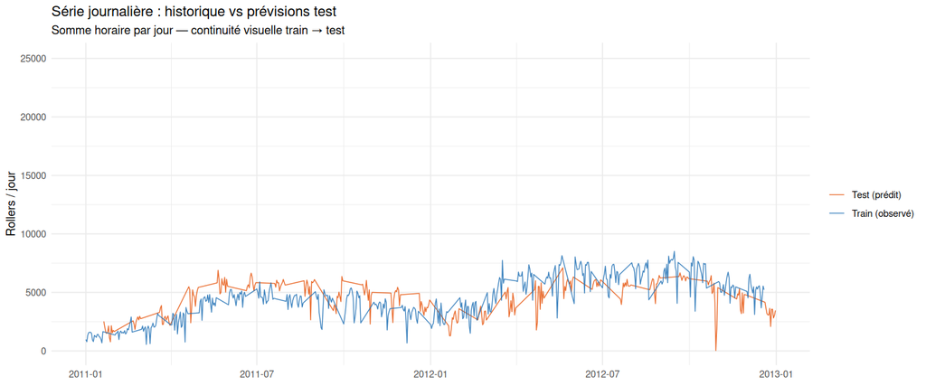

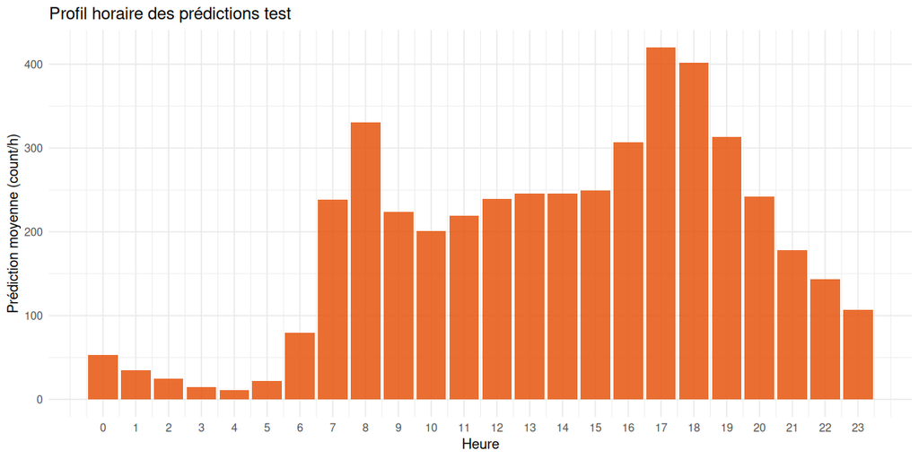

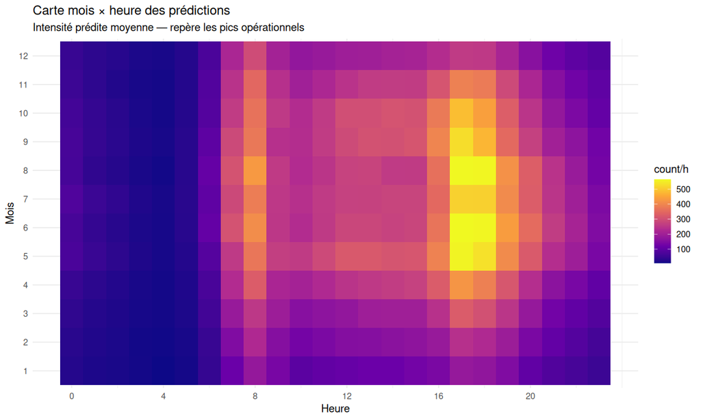

**Analyse des données agrégées :**

- Série journalière train + test → vision globale de la dynamique.
- Profil horaire prédit → planification opérationnelle (staff, stock).
- Heatmap mois × heure → identification des créneaux critiques.